# Homeworks1

Liu Dingding

2021/12/17

## Question

Use knitr to produce at least 3 examples(texts,figures,tables).

## Answer

读取1920年代汽车速度对刹车距离的影响,打印前10组数据，并将两者的部分统计量以表格形式输出

```r
df<-cars
print(df[1:10,])
```

```
##    speed dist
## 1      4    2
## 2      4   10
## 3      7    4
## 4      7   22
## 5      8   16
## 6      9   10
## 7     10   18
## 8     10   26
## 9     10   34
## 10    11   17
```

```r
knitr::kable(summary(df))
```

|  | speed | dist |
| --- | --- | --- |
|  | Min. : 4.0 | Min. : 2.00 |
|  | 1st Qu.:12.0 | 1st Qu.: 26.00 |
|  | Median :15.0 | Median : 36.00 |
|  | Mean :15.4 | Mean : 42.98 |
|  | 3rd Qu.:19.0 | 3rd Qu.: 56.00 |
|  | Max. :25.0 | Max. :120.00 |

绘制速度与刹车距离的散点图,并用最小二乘法线性拟合

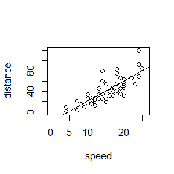

```r
x=df[,"speed"]
y=df[,"dist"]
plot(x,y,xlab="speed",ylab="distance",xlim=c(0,max(df$speed)+1),ylim=c(0,max(df$dist)+1),'p')
model<-lm(y~x,data=df)
abline(model)
```

## Question

Exercises 3.9,3.11, 3.20.

## Answer

3.9

写一个函数生成随机变量，服从密度函数：
$$f_e=\frac{3}{4}(1-x^2),|x|\le1$$

```r
fe<-function(){
  u<-runif(3,-1,1)#生成服从均匀分布U(-1,1)的三个随机数
  uabs=abs(u)#绝对值化
  indx<-which(uabs==max(uabs))#找绝对值化后最大值的下标
  u2=u[-indx]#去掉绝对值最大的数
  u2[2]#输出需要的随机数
}
```

构造一个样本量为1000的大模拟随机样本的密度估计的直方图:

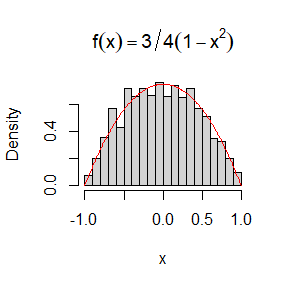

```r
library(MASS)
x<-1:1000
for(i in 1:1000){
 x[i]<-fe()
}
hist(x,prob=TRUE,breaks=20,main=expression(f(x)==3/4*(1-x^2)))
x1<-seq(-1,1,.01)
lines(x1,col="red",3/4*(1-x1^2))
```

从直方图和密度图可以看出，经验分布和理论分布较吻合.

3.11

生成1000个服从正态位置混合变量的随机样本，混合变量分别服从$N(0,1)$和$N(3,1)$，混合密度为$p_1,p_2=1-p_1$

当$p_1=0.75$时，$p_2=0.25$，对应的叠加密度曲线直方图如下：

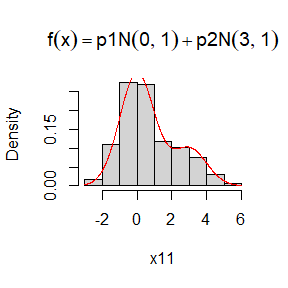

```r
ppnorm<-function(p1,p2){
  ber<-sample(0:1,size=1000,replace=TRUE,prob=c(p2,p1))
  x11<-1:1000
  for(i in 1:1000){
    x11[i]<-ber[i]*rnorm(1,0,1)+(1-ber[i])*rnorm(1,3,1)
  }
  hist(x11,prob=TRUE,main=expression(f(x)==p1*N(0,1)+p2*N(3,1)))
  y<-seq(floor(min(x11)),ceiling(max(x11)),0.01)
  lines(y,p1*dnorm(y,0,1)+p2*dnorm(y,3,1),col="red")
}
ppnorm(.75,.25)
```

当$p_1=0.75$时，可以看到不明显双峰.

下面对不同的$p_1$进行观测：

```r
par(mfrow=c(1,3))
for(i in 1:9){
  p<-i/10
  ppnorm(p,1-p)
}
```

[figure not shown]

[figure not shown]

[figure not shown]

通过图像可以看出，$p_1$在[0.25,0.75]范围可以观测到双峰,此为大致范围，并不精确

3.20

模拟混合$Poisson-Gamma$过程,$Gamma$分布的参数固定为$alpha=1,rate=1$：

```r
pogam<-function(lmd,alpha=1,rate=1){#模拟混合分布算法
  t0<-10
  tn<-rexp(100,lmd)
  sn<-cumsum(tn)
  n<-min(which(sn>t0))
  xt<-rgamma(n,1,1)
  sum(xt)
}
lmd<-2#给参数lambda赋值
pg<-1:1000
for(i in 1:1000){
  pg[i]<-pogam(lmd,alpha,rate)
}#生成1000个混合分布的随机样本
```

对于理论均值和方差，有$E[Y_1]=D[Y_1]=1,E[Y_1^2]=2$，则$E[X(t)]=\lambda*10*E[Y_1]=10\lambda,Var[X(t)]=\lambda*10*E[Y_1^2]=20\lambda$， 打印$\lambda=1,2,3,4,5$时样本均值、样本方差和理论均值、理论方差，进行比较：

```r
tab1<-matrix(0,3,5)
tab2<-matrix(0,3,5)
row1<-c('λ','样本均值','理论均值')
row2<-c('λ','样本方差','理论方差')
dimnames(tab1)<-list(row1,c('','','','',''))
dimnames(tab2)<-list(row2,c('','','','',''))
for(i in 1:5){
  lmd<-i
  p<-pogam(lmd)
  m_p<-mean(p)#样本均值
  s_p<-var(p)#样本方差
  m<-10*lmd
  s<-20*lmd
  tab1[,i]<-c(i,m_p,m)
  tab2[,i]<-c(i,s_p,s)
}

knitr::kable(tab1)
```

| λ | 1.00000 | 2.00000 | 3.00000 | 4.0000 | 5.00000 |
| --- | --- | --- | --- | --- | --- |
| 样本均值 | 23.66155 | 30.16855 | 27.90329 | 31.9486 | 71.52266 |
| 理论均值 | 10.00000 | 20.00000 | 30.00000 | 40.0000 | 50.00000 |

```r
knitr::kable(tab2)
```

| λ | 1 | 2 | 3 | 4 | 5 |
| --- | --- | --- | --- | --- | --- |
| 样本方差 | NA | NA | NA | NA | NA |
| 理论方差 | 20 | 40 | 60 | 80 | 100 |

## Question

Exersice 5.4,5.9,5.13and5.14

## Anwser

5.4:

写一个函数，使用蒙特卡洛积分方法估计$Beta(3,3)$的$cdf$：

```r
beta_cdf<-function(x,m=1000){
  u<-runif(m)
  cdf<-numeric(length(x))
  for(i in 1:length(x)){
    g<-u^2*x[i]^3*(1-u*x[i])^2
    cdf[i]<-mean(g)/beta(3,3)
  }
  cdf
}
```

得到在$x=0.1,0.2,...,0.9$处的估计值以及真实值，并进行比较：

```r
set.seed(1)
x<-seq(0.1,0.9,length=9)
CDF<-beta_cdf(x)
beta_real<-pbeta(x,3,3)
knitr::kable(round(rbind(x,CDF,beta_real),3))
```

| x | 0.100 | 0.200 | 0.300 | 0.400 | 0.500 | 0.600 | 0.700 | 0.800 | 0.900 |
| --- | --- | --- | --- | --- | --- | --- | --- | --- | --- |
| CDF | 0.009 | 0.058 | 0.163 | 0.316 | 0.498 | 0.680 | 0.834 | 0.939 | 0.991 |
| beta_real | 0.009 | 0.058 | 0.163 | 0.317 | 0.500 | 0.683 | 0.837 | 0.942 | 0.991 |

从表格可以看出，估计值与真实值相差不大.

5.9:

对偶变量法写函数生成样本，使其服从分布密度函数$f(x)=\frac{x}{\sigma^2}e^{-x^2/(2\sigma^2)},x\ge0,\sigma>0$:

```r
MC.ray<-function(x,s,R=10000,antithetic=TRUE){
  u<-runif(R/2)
  if(!antithetic) v<-runif(R/2)
  else v<-1-u
  u<-c(u,v)
  cdf<-numeric(length(x))
  for(i in 1:length(x)){
    g<-u*x[i]^2*exp(-(u*x[i])^2/(2*s^2))
    cdf[i]<-mean(g)/s^2
  }
  cdf

}
```

给定$\sigma=1$单一蒙特卡罗实验和对偶蒙特卡罗实验的估计值对比如下：

```r
x<-seq(.1,2.5,length=10)
set.seed(2)
MC1<-MC.ray(x,s=1,antithetic = FALSE)
MC2<-MC.ray(x,s=1)
knitr::kable(round(rbind(x,MC1,MC2),4))
```

| x | 0.100 | 0.3667 | 0.6333 | 0.9000 | 1.1667 | 1.4333 | 1.7000 | 1.9667 | 2.2333 | 2.5000 |
| --- | --- | --- | --- | --- | --- | --- | --- | --- | --- | --- |
| MC1 | 0.005 | 0.0654 | 0.1827 | 0.3345 | 0.4953 | 0.6431 | 0.7642 | 0.8537 | 0.9139 | 0.9507 |
| MC2 | 0.005 | 0.0650 | 0.1816 | 0.3325 | 0.4923 | 0.6395 | 0.7603 | 0.8500 | 0.9107 | 0.9485 |

对于给定$x=1.5$，分别用单一蒙特卡罗积分法和对偶变量法来模拟估计方差缩减量，并计算方差缩减量的百分比：

```r
m<-1000
MC1<-MC2<-numeric(m)
x<-1.5
for(i in 1:m){
  MC1[i]<-MC.ray(x,s=1,R=1000,antithetic = FALSE)
  MC2[i]<-MC.ray(x,s=1,R=1000)
}
print(sd(MC1))
```

```
## [1] 0.008237815
```

```r
print(sd(MC2))
```

```
## [1] 0.00685426
```

```r
print((var(MC1)-var(MC2))/var(MC1))
```

```
## [1] 0.3076958
```

在$x=1.5$处，对偶变量法得到30%左右的方差缩减量.

5.13

找到两个重要函数$f_1,f_2$接近$g(x)=\frac{x^2}{\sqrt{2\pi}}e^{-x^2/2},x>1$，其中$f_1(x)=2f(x),x>1,f(x)$为正态分布$N(1,1)$密度函数，$f_2(x)=e^{(1-x)},x>1$，为定义区间在$(1,+\infty)$指数分布：

```r
m<-10000
theta.hat<-se<-numeric(2)
g<-function(x){
  x^2/sqrt(2*pi)*exp(-x^2/2)
}
f1<-function(x){2*dnorm(x,1,1)*(x>=1)}
f2<-function(x){
  exp(1-x)
}
x1<-abs(rnorm(m,0,1))+1
x2<-rexp(m,1)+1
fg1<-g(x1)/f1(x1)
fg2<-g(x2)/f2(x2)
theta.hat[1]<-mean(fg1)
theta.hat[2]<-mean(fg2)
se[1]<-sd(fg1)
se[2]<-sd(fg2)
rbind(theta.hat,se)#得到估计值和标准差
```

```
##                 [,1]      [,2]
## theta.hat 0.40084345 0.3976961
## se        0.04405607 0.1593917
```

模拟结果显示，两个重要函数中$f_1$产生的方差更小.

下面画出$g,f_1,f_2$的图像$figure(a)$以及比例$g/f_1,g/f_2$的图像$figure(b)$

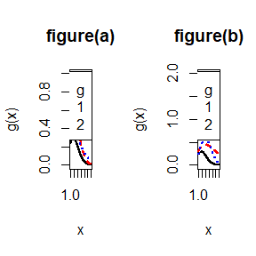

```r
x<-seq(1,4,0.01)
par(mfrow=c(1,2))
#figue(a)
plot(x,g(x),type="l",main="figure(a)",ylim=c(0,1),lwd=2)
lines(x,f1(x),lty=2,lwd=2,col="red")
lines(x,f2(x),lty=3,lwd=2,col="blue")
legend("topright",legend=c("g",1:2),lty=1:3,lwd=2,inset=0.02)
#figue(b)
plot(x,g(x),type="l",main="figure(b)",ylim=c(0,2),lwd=2)
lines(x,g(x)/f1(x),lty=2,lwd=2,col="red")
lines(x,g(x)/f2(x),lty=3,lwd=2,col="blue")
legend("topright",legend=c("g",1:2),lty=2:3,lwd=2,inset=0.02)
```

从图像可以看出，红色所代表的$g/f_1$波动更小，更趋近于一个常数，所以$f_1$产生的方差更小.

5.14

在5.13中，$f_1$的方差更小，根据它使用重要抽样方法得到$g(x)=\frac{x^2}{\sqrt{2\pi}}e^{-x^2/2},x>1$的蒙特卡罗估计为：

```r
print(theta.hat[1])
```

```
## [1] 0.4008434
```

## Question 6.5

Suppose a 95% symmetric t-interval is applied to estimate a mean, but the sample data are non-normal. Then the probability that the confidence interval covers the mean is not necessarily equal to 0.95.

Use a Monte Carlo experiment to estimate the coverage probability of the t-interval for random samples of $\chi^2(2)$ data with sample size $n = 20$.

Compare your t-interval results with the simulation results in Example 6.4.

## Answer

If $X_1,...,X_n$ is a random sample from a Normal distrbution $N(\mu,\sigma^2)$,$n\ge2$, $\overline{X}$ is the sample mean ,and $S^{2}$ is the sample variance,then
$$U=\frac{\sqrt{n}(\overline{X}-\mu)}{S} \sim t(n-1) \tag{1}$$
.

A two sides $100(1-\alpha)\%$ CI is given by
$$(\overline{X}-\frac{S}{\sqrt{n}}t_{\alpha/2}(n-1),\overline{X}+\frac{S}{\sqrt{n}}t_{\alpha/2}(n-1))$$

Suppose that sampled population is $\chi^2(2)$,which has mean 2 and variance 4.We use the $\chi^2(2)$samples to simulate.

In this plce we have $\mu=2,\sigma=2,n=20,m=1000,and\alpha=0.05$:

```r
set.seed(1)
n<-20
I<-replicate(1000,expr={
  x<-rchisq(n,df=2)
  se<-sqrt(var(x))
  UCL1<-mean(x)-se/sqrt(n)*qt(.975,df=n-1)#CI lower
  UCL2<-mean(x)+se/sqrt(n)*qt(.975,df=n-1)#CI upper
  (UCL2>2)*(UCL1<2)# mean 2 of chisq is in CI or not
})
sum(I)
```

```
## [1] 926
```

```r
mean(I)
```

```
## [1] 0.926
```

From the result,92.6% of the intervals contained the population mean.

And in example 6.4,the coverage probability of the variance is 77.3%.

we can conclude that the t-interval should be more robust to departures from normality than the interval for variance.

## Question 6.A

Use Monte Carlo simulation to investigate whether the empirical Type I error rate of the t-test is approximately equal to the nominal significance level α, when the sampled population is non-normal. The t-test is robust to mild departures from normality. Discuss the simulation results for the cases where the sampled population is $(i) \chi^2(1), (ii) Uniform(0,2), and (iii) Exponential(rate=1)$. In each case, test $H_0 : \mu = \mu_0 vs H_1 : \mu \ne \mu_0$, where $\mu_0$ is the mean of $\chi^2(1), Uniform(0,2), and Exponential(1)$, respectively.

## Answer

In this question,$\mu_0=1$,test
$$H_0 : \mu =1 vs H_1 : \mu \ne 1$$

```r
set.seed(2)
n<-c(10,20,30,50,100,500,1000)#a vector of sample sizes
p1.hat<-p2.hat<-p3.hat<-numeric(length(n))#to store TYPE I ERROR for different n
m<-10000#num. repl. each sim.
for(i in 1:length(n)){
  p3<-p2<-p1<-numeric(m)
  se3<-se2<-se1<-numeric(m)
  for(j in 1:m){
    x1<-rchisq(n[i],df=1)
    x2<-runif(n[i],0,2)
    x3<-rexp(n[i],rate=1)
    ttest1<-t.test(x1,alternative="two.sided",mu=1)
    ttest2<-t.test(x2,alternative="two.sided",mu=1)
    ttest3<-t.test(x3,alternative="two.sided",mu=1)
    p1[j]<-ttest1$p.value
    p2[j]<-ttest2$p.value
    p3[j]<-ttest3$p.value
  }
  p1.hat[i]<-mean(p1<0.05)
  p2.hat[i]<-mean(p2<0.05)
  p3.hat[i]<-mean(p3<0.05)
}
se1<-sqrt(p1.hat*(1-p1.hat)/m)
se2<-sqrt(p2.hat*(1-p2.hat)/m)
se3<-sqrt(p3.hat*(1-p3.hat)/m)
options(scipen=10)
print(round(rbind(n,p1.hat,se1,p2.hat,se2,p3.hat,se3),7))
```

```
##              [,1]       [,2]       [,3]       [,4]        [,5]        [,6]
## n      10.0000000 20.0000000 30.0000000 50.0000000 100.0000000 500.0000000
## p1.hat  0.1384000  0.1051000  0.0871000  0.0793000   0.0662000   0.0588000
## se1     0.0034532  0.0030668  0.0028198  0.0027021   0.0024863   0.0023525
## p2.hat  0.0494000  0.0543000  0.0497000  0.0508000   0.0472000   0.0510000
## se2     0.0021670  0.0022661  0.0021732  0.0021959   0.0021207   0.0022000
## p3.hat  0.0964000  0.0781000  0.0697000  0.0712000   0.0588000   0.0503000
## se3     0.0029514  0.0026833  0.0025464  0.0025716   0.0023525   0.0021856
##                [,7]
## n      1000.0000000
## p1.hat    0.0517000
## se1       0.0022142
## p2.hat    0.0493000
## se2       0.0021649
## p3.hat    0.0502000
## se3       0.0021836
```

From the results,we can see the empirical Type I error rate of Uniform(0,2) is more approximately equal to 0.05 than the other two distributions. The uniform is more mild departures from normality.

## Question1 in class

If we obtain the powers for two methods under a particular simulation setting with 10,000 experiments: say, 0.651 for one method and 0.676 for another method. We want to know if the powers are different at 0.05 level.

## Anwser

we can’t say the powers are different at 0.05 level.Different methods have different standard error.

## Question2 in class

What is the corresponding hypothesis test problem?

## Anwser

相关性检验，常依据相关系数构造假设，相关系数是研究变量之间线性相关程度的量，用于说明两个变量之间是否存在相关关系，以及相关关系的紧密程度。常见的检验是对相关系数是否等于0作出假设(常见的有pearson相关系数、Spearman相关系数、kendal秩相关系数、线性回归模型的$\beta_1$)。

## Question3 in class

What test should we use? Z-test, two-sample t-test, paired-test or McNemar-test? Why?

Please provide the least necessary information for hypothesis testing.

## Anwser

Z-test:一般用于大样本平均值差异性检验，或者已知前提两样本独立的正态分布且方差已知，用标准正态分布的理论来推断差异发生的概率，从而比较均值差异是否显著.

the least necessary information for Z-test：大样本或者已知前提两样本独立的正态分布且方差已知

two-sample t-test:检验两个正态分布的样本均值差异是否显著

the least necessary information for two-sample t-test：两样本独立且服从正态分布，方差未知

paired-test：研究对象的前后两次测量，两样本是1：1配对出现的，针对研究对象前后的两次测量差异是否显著

the least necessary information for paired-test：两样本配对，服从正态分布或近似正态分布，均值比较时要求总体方差齐性.

McNemar-test：即配对卡方检验，适用于二分类问题，用于某些2*2表格的配对样本，在比较两个二元分类算法时，用于比较两个模型的差异性，不能说明哪个模型更准确。

the least necessary information for McNemar-test：待检验两组样本的观察值是二分类数据

## Question 6.C

Repeat Examples 6.8 and 6.10 for Mardia’s multivariate skewness test. If $X$ and $Y$ are $iid$, the multivariate population skewness $\beta_{1,d}$ is defined by Mardia as
$$\beta_{1,d}=E[(X-\mu)^T\Sigma^{-1}(Y-\mu)^3]$$
. Under normality, $\beta_{1,d}=0$. The multivariate skewness statistic is
$$b_{1,d}=\frac{1}{n^2}\sum_{i,j=1}^{n}((X_i-\overline{X})^T\hat{\Sigma}^{-1}(X_j-\overline{X}))^3$$
where $\hat{\Sigma}$ is the maximum likelihood estimator of covariance. Large values of $b_{1,d}$ are significant. The asymptotic distribution of $nb_{1,d}/6$ is chisquared with $d(d + 1)(d + 2)/6$ degrees of freedom.

## Anwser

检验水平固定为$\alpha=0.05$，$nb_{1,d}/6$ 的渐近分布是自由度为$d(d + 1)(d + 2)/6$的卡方分布，

对$n=(20,30,50,100,500)$，先在极限分布下计算临界值向量cv.

```r
n<-c(20,30,50,100,500)#n是试验中样本量组成的向量
d=3
cv<-qchisq(.95,df=d*(d+1)*(d+2)/6)
```

接下来写一个函数来计算样本偏度统计量.

```r
library(MASS)
sk<-function(x){
  Sigma.hat<-(nrow(x)-1)*cov(x)/nrow(x)#协方差矩阵的极大似然估计
  sigma.ni<-ginv(Sigma.hat)
  x.new=x
  for(i in 1:d){
    x.new[,i]<-x[,i]-mean(x[,i])
  }
  y<-(x.new%*%sigma.ni%*%t(x.new))^3
  nrow(x)*mean(y)/6
}
```

在下面代码中，循环改变样本大小n，循环内对n进行模拟，检验决策（1或0）的均值储存在“p.reject”中

```r
m<-1e4
set.seed(111)
mean<-rep(0,d);sigma<-diag(d)#标准正态分布的均值和协方差
p.reject<-numeric(length(n))
for(i in 1:length(n)){
     p.reject[i]<-mean(replicate(m,expr={
       x<-mvrnorm(n[i],mean,sigma)#抽n[i]个向量样本,服从多元标准正态分布
       as.integer(sk(x)>=cv)}))
}
print(rbind(n,p.reject))
```

```
##            [,1]    [,2]    [,3]     [,4]     [,5]
## n        20.000 30.0000 50.0000 100.0000 500.0000
## p.reject  0.021  0.0349  0.0406   0.0513   0.0501
```

由模拟的结果可知当样本量$n\ge100$时，第一类错误率的估计值接近理论水平$\alpha=0.05$.

接下来考虑偏度正态检验的功效:

针对污染正态分布:
$$(1-\epsilon)N(\mu_1,\Sigma_1)+\epsilon N(\mu_2,\Sigma_2)$$
, 其中
$$\mu_1=\mu_2=(0,0,0)$$
$$\Sigma_1=\begin{pmatrix}
1&0&0\\
0&1&0\\
0&0&1\\
\end{pmatrix}
\Sigma_2=\begin{pmatrix}
100&0&0\\
0&100&0\\
0&0&100\\
\end{pmatrix}$$
当$\epsilon=0,1$时分布时正态的，当$0<\epsilon<1$时是非正态的.

对一系列$\epsilon$的备择假设估计其偏度估计检验的功效，并绘制偏度检验功效的功效曲线.

显著水平$\alpha=0.05$，样本大小$n=30$

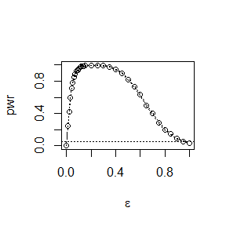

```r
set.seed(1)
n<-30
m<-2500
epsilon<-c(seq(0,0.15,0.01),seq(0.15,1,0.05))
N<-length(epsilon)
pwr<-numeric((N))#储存不同epsilon对应的功效值
mu2<-mu1<-c(0,0,0)
s1<-diag(3)
s2<-diag(3)*100
for(i in 1:N){
  e<-epsilon[i]
  pwr[i]<-mean(replicate(m,expr={
    r<-sample(c(0,1),size=n,replace=TRUE,prob=c(1-e,e))
    x<-(1-r)*mvrnorm(1,mu1,s1)+ r*mvrnorm(n,mu2,s2)
    as.integer(sk(x)>=cv)
  }))
}

#plot power(pwr) vs epsilon
plot(epsilon,pwr,type="b",xlab=bquote(epsilon),ylim=c(0,1))
abline(h=0.05,lty=3)
se<-sqrt(pwr*(1-pwr)/m)#add se
lines(epsilon,pwr+se,lty=3)
lines(epsilon,pwr-se,lty=3)
```

```r
epsilon[which(pwr==max(pwr))]#power最大值对应的epsilon
```

```
## [1] 0.25
```

由经验功效曲线可以看出，当$0<\epsilon<1$时在$\epsilon=0.25$左右功效达到最大值，并且接近于1.

## Question 7.7

Refer to Exercise 7.6,The five-dimensional scores data have a 5 × 5 covariance matrix $\Sigma$, with positive eigenvalues $\lambda_1 > ··· > \lambda_5$. In principal components analysis,
$$\theta=\frac{\lambda_1}{\sum_{j=1}^{5}\lambda_j}$$
measures the proportion of variance explained by the first principal component.Let $\hat{\lambda_1 }> ··· > \hat{\lambda_5}$ be the eigenvalues of $\hat{\Sigma}$, where $\hat{\Sigma}$ is the MLE of $\Sigma$. Compute the sample estimate
$$\hat{\theta}=\frac{\hat{\lambda_1}}{\sum_{j=1}^{5}\hat{\lambda_j}}$$
of $\theta$. Use bootstrap to estimate the bias and standard error of $\hat{\theta}$.

## Anwser 7.7

```r
set.seed(1)
library(bootstrap)#for the score data
library(MASS)
library(boot)
#write a function to compute the theta
theta.boot<-function(score,i){
  x<-score[i,]
  n<-nrow(score)#sample size
  #cov(x)-unbised estimator,need to *(n-1)/n to get MLE
  lmd<-eigen((n-1)*cov(x)/n)$values#vector of values
  lmd[1]/sum(lmd)#return estimator of theta according to score
}

#bootstrap
B<-1000#number of replicates
n<-nrow(scor)#sample size
lmd.hat<-eigen((n-1)*cov(scor)/n)$values
theta.hat<-lmd.hat[1]/sum(lmd.hat)
R<-numeric(B)
result<-boot(data=scor,statistic=theta.boot,R=1000)
theta_b<-result$t#extract the replicates in $t
bias_b<-mean(theta_b)-theta.hat# Bootstrap Estimation of Bias
se_b<-sd(theta_b)#Bootstrap Estimation of Standard Error
print(cbind(theta.hat,theta_boots=mean(theta_b),bias_boots=bias_b,se_boots=se_b))
```

```
##      theta.hat theta_boots  bias_boots   se_boots
## [1,]  0.619115   0.6212793 0.002164245 0.04617253
```

## Question 7.8

Refer to Exercise 7.7. Obtain the jackknife estimates of bias and standard error of $\hat{\theta}$.

## Anwser 7.8

```r
#JACKknife
set.seed(2)
theta.jack<-numeric(n)#store JACKknife estimation of theta
for(i in 1:n){
  x<-scor[-i,]#delet the ith data to get a set of JACKKNIFE samples
  lmd.J<-eigen((n-1)*cov(x)/n)$values#values of MLE of Sigma
  theta.jack[i]<-lmd.J[1]/sum(lmd.J)
}
theta_j<-mean(theta.jack)
bias_j<-(n-1)*(mean(theta.jack)-theta.hat)
se_j<-sqrt((n-1)*mean((theta.jack-mean(theta.jack))^2))
print(cbind(theta.hat,theta_j,bias_j,se_j))
```

```
##      theta.hat   theta_j      bias_j       se_j
## [1,]  0.619115 0.6191273 0.001069139 0.04955231
```

The estimator of the bias of $\hat{\theta}$ is $0.001069139$ using Jackknife.

The estimator of standard error of $\hat{\theta}$ is $0.04955231$ using Jackknife.

## Question 7.9

Refer to Exercise 7.7. Compute 95% percentile and BCa confidence intervals for $\hat{\theta}$.

## Anwser 7.9

In 7.7,we use BOOTSTRAP.Function ‘boot’ and ‘boot.ci’ in package “boot” can help us to obtain the 95% percentile and BCa bootstrap confidence intervals.

```r
#result is by bootstrap in 7.7
print(result)
```

```
##
## ORDINARY NONPARAMETRIC BOOTSTRAP
##
##
## Call:
## boot(data = scor, statistic = theta.boot, R = 1000)
##
##
## Bootstrap Statistics :
##     original      bias    std. error
## t1* 0.619115 0.002164245  0.04617253
```

```r
print(boot.ci( result,conf = 0.95,type=c("perc","bca")))
```

```
## BOOTSTRAP CONFIDENCE INTERVAL CALCULATIONS
## Based on 1000 bootstrap replicates
##
## CALL :
## boot.ci(boot.out = result, conf = 0.95, type = c("perc", "bca"))
##
## Intervals :
## Level     Percentile            BCa
## 95%   ( 0.5263,  0.7085 )   ( 0.5234,  0.7035 )
## Calculations and Intervals on Original Scale
```

## Question 7.B

7.A :Conduct a Monte Carlo study to estimate the coverage probabilities of the standard normal bootstrap confidence interval, the basic bootstrap confidence interval, and the percentile confidence interval. Sample from a normal population and check the empirical coverage rates for the sample mean. Find the proportion of times that the confidence intervals miss on the left, and the porportion of times that the confidence intervals miss on the right.

7.B :Repeat Project 7.A for the sample skewness statistic. Compare the coverage rates for normal populations (skewness 0) and $\chi^2(5)$ distributions (positive skewness).

## Anwser 7.B

First,couduct a Mont Carlo study:

Suppose that $X ∼ F_X$ is the random variable of interest and that $\theta$ is the target parameter to be estimated.

1.For each replicate, indexed j = 1,…,m:

1. Generate the $j^{th}$ random sample, $X^{(j)}_1 ,…,X^{(j)}_n $.
2. Compute the standard normal bootstrap confidence interval, the basic bootstrap confidence interval, and the percentile confidence interval $N_j,B_j,P_j$ for the $j^{th}$ sample.
3. Compute $n_j = I(\theta ∈ N_j ),b_j = I(\theta ∈ B_j ),p_j = I(\theta ∈ P_j )$ for the $j^{th}$ sample.

2.Compute the the coverage probabilities$\overline{n}=\frac{1}{m}\Sigma_{j=1}^{m}n_j,\overline{b}=\frac{1}{m}\Sigma_{j=1}^{m}b_j,\overline{p}=\frac{1}{m}\Sigma_{j=1}^{m}p_j$ .

Next,we realize the project for the sample skewness statistic.

```r
m=500#Mont carlo study times
n=100#sample size
sk.chi<-sqrt(8/5)#skweness of Chi-square distribution with df=5
sk<-function(x){
  #compute the sample skewness coeff
  xbar<-mean(x)
  m3<-mean((x-xbar)^3)
  m2<-mean((x-xbar)^2)
  return(m3/m2^1.5)
}
skew.boot<-function(data,i){
  #function to compute the statistic
  x<-data[i,]
  sk(x)
}
x.cp<-y.cp<-numeric(m)#store decision values (0or1) for theta is in CI or not.
norm_prob<-numeric(9)#store coverage prob and proportion of times of miss on the two sides about N(0,1)
chis_prob<-numeric(9)#store coverage prob and proportion of times of miss on the two sides about N(0,1)
set.seed(3)
x.cp<-replicate(500,expr={
  x<-rnorm(n,0,1)
  x<-matrix(x)
  boot.x<-boot(x,statistic = skew.boot,R=1000)
  ci=boot.ci(boot.x,conf = 0.95,type=c("norm","basic","perc"))
  x.p<-(ci$perc[4]<0)*(0<ci$perc[5])#theta=0 is in perc CI or not
  x.b<-(ci$basic[4]<0)*(0<ci$basic[5])#0 is basic CI or not
  x.n<-(ci$norm[2]<0)*(0<ci$norm[3])#0 is in normal CI or not
  x.pleft<-(ci$perc[4]>=0)*1;x.pright<-(ci$perc[5]<=0)*1
  x.bleft<-(ci$basic[4]>=0)*1;x.bright<-(ci$basic[5]<=0)*1
  x.nleft<-(ci$normal[2]>=0)*1;x.nright<-(ci$normal[3]<=0)*1
  list(x.n,x.b,x.p,x.nleft,x.bleft,x.pleft,x.nright,x.bright,x.pright)
})
for(i in 1:9){
  norm_prob[i]<-mean(as.numeric(x.cp[i,]))
}
y.cp<-replicate(500,expr={
  y<-rchisq(n,df=5)
  y<-matrix(y)
  boot.y<-boot(y,statistic = skew.boot,R=2000)
  ci=boot.ci(boot.y,conf = 0.95,type=c("norm","basic","perc"))
  y.b<-(ci$basic[4]<sk.chi)*(sk.chi<ci$basic[5])#theta= is basic CI or not
  y.n<-(ci$norm[2]<sk.chi)*(sk.chi<ci$norm[3])#0 is in normal CI or not
  y.p<-(ci$perc[4]<sk.chi)*(sk.chi<ci$perc[5])#0 is in perc CI or not
  y.pleft<-(ci$perc[4]>=sk.chi)*1;y.pright<-(ci$perc[5]<=sk.chi)*1
  y.bleft<-(ci$basic[4]>=sk.chi)*1;y.bright<-(ci$basic[5]<=sk.chi)*1
  y.nleft<-(ci$normal[2]>=sk.chi)*1;y.nright<-(ci$normal[3]<=sk.chi)*1
  list(y.n,y.b,y.p,y.nleft,y.bleft,y.pleft,y.nright,y.bright,y.pright)
})
for(i in 1:9){
  chis_prob[i]<-mean(as.numeric(y.cp[i,]))
}
coverprob=matrix(c(norm_prob[1:3],chis_prob[1:3]),byrow=TRUE,nrow=2)
norm_miss=matrix(norm_prob[4:9],byrow=TRUE,nrow=2)
chis_miss=matrix(chis_prob[4:9],byrow=TRUE,nrow=2)
row.names(coverprob)<-c("normal_distrib","chis_distrib")
row.names(norm_miss)<-row.names(chis_miss)<-c("left_miss_proportion","right_miss_proportion")
colnames(coverprob)<-colnames(norm_miss)<-colnames(chis_miss)<-c("norm CI","basic CI","perc CI")
```

Print the coverage probabilities of the standard normal bootstrap confidence interval, the basic bootstrap confidence interval, and the percentile confidence interval of distribution N(0,1) and chis-distribution with df=5.

```r
print(coverprob)#coverage probability of three kinds CI for two different distributions
```

```
##                norm CI basic CI perc CI
## normal_distrib   0.908    0.904   0.922
## chis_distrib     0.818    0.786   0.800
```

(2)Coverage prob of the three kinds CI of normal distribution is higer than chis-distribution.

Then we find the proportion of times that the confidence intervals miss on the left, and the porportion of times that the confidence intervals miss on the right as below:

```r
print(norm_miss)#proportion of times of miss on the two sides about N(0,1)
```

```
##                       norm CI basic CI perc CI
## left_miss_proportion    0.050    0.054   0.044
## right_miss_proportion   0.042    0.042   0.034
```

```r
print(chis_miss)#proportion of times of miss on the two sides about chis-distribution with df=5
```

```
##                       norm CI basic CI perc CI
## left_miss_proportion    0.020    0.050     0.0
## right_miss_proportion   0.162    0.164     0.2
```

From the result,for normal distribution,we can see that the proportion of times that the confidence intervals miss on the left is close to that on the right.

But,for chis-distribution,the proportion of times that the confidence intervals miss on the right is obviously larger than that on the left.

And considering the fact that the skewness of normal distribution is 0 and the skewness of chis-distribution is positive.So the result is valid.And the Mont carlo stduy we conduct is valid.